# Individual Student Report

2021-09-28

## Dear Parents/Guardians,

These results provide information about where your student is performing on grade level standards, and/or expectations, and skills. A student’s overall score and corresponding achievement levels are displayed in the line graph.

Oregon teachers and administrators have worked to implement more challenging, relevant, and engaging English and math standards in every K-12 classroom. These standards identify what students should know or be able to do to graduate high school on a path ready for college and career.

If you have questions about these results or how to best support your child, please contact your child’s school.

2018-19

OREGON STATEWIDE ASSESSMENT

Susan B. Anthony

| var | id | values |
| --- | --- | --- |
| SSID |  | 9878654321 |
| Grade |  | 5 |
| Birthdate |  | 9/1/2002 |
| Test Date |  | 3/13/2019 |
| Teacher |  | Daniel Anderson |
| School | 1234 | Apple High School |
| District | 5678 | Cherry SD |
| County | 99 | Grape |

Unofficial

Table 1: Your child’s scores and achievement levels

| grade | l1 | l2 | l3 | l4 |
| --- | --- | --- | --- | --- |
| Grade 5 | Level 1 Less than 506 | Level 2 506 - 516 | Level 3 517 - 529 | Level 4 530 or more |

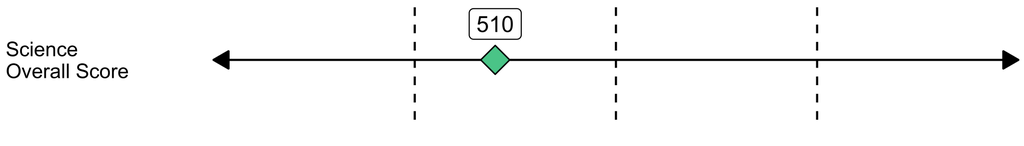

The student demonstrates inconsistent or partial mastery when presented with test items linked to grade level content; i.e., content that has been reduced in depth, breadth, and complexity. Specific information regarding your student’s performance in each domain of this assessment are located in the Achievement/Performance Standards section on the Statewide Alternate Assessment website: https://www.oregon.gov/ode/educator-resources/assessment/AltAssessment/. Note: Because your child participated in the Extended Assessment, these results cannot be used to compare your child’s performance with that of students who are in the same enrolled grade but taking the general assessment.

ODE worked with partners at the University of Oregon at Behavioral Research & Teaching, along with education and community partners, to develop parent assessment literacy training modules found at: https://www.oregon.gov/ode/educator-resources/assessment/Pages/asmtlit.aspx

## About scale scores and achievement standards

Student results are reported on scales that vary by test subject. Standards have been established with respect to these score s that identify your child’s achievement level. A description of this achievement level is provided below the score(s). For more information on scores and achievement standards, see https://www.oregon.gov/ode/educator-resources/standards/Pages/Achievement-Performance-Standards.aspx.